# Final Project

## 6.2 Model Fitting and Diagnostic Checking

### 6.2.1 Parameter significance

#### SARIMA(0, 1, 1)(0, 1, 3)_12

```r
# SARIMA(0,1,1)x(0,1,3)_12
# ML METHOD
m4_011_ML <- Parameter.estimation(Data_ts_agg,c(0,1,1),c(0,1,3),method="ML",'25')
```

```
##
##  Shapiro-Wilk normality test
##
## data:  res.model
## W = 0.95234, p-value = 0.01036
```

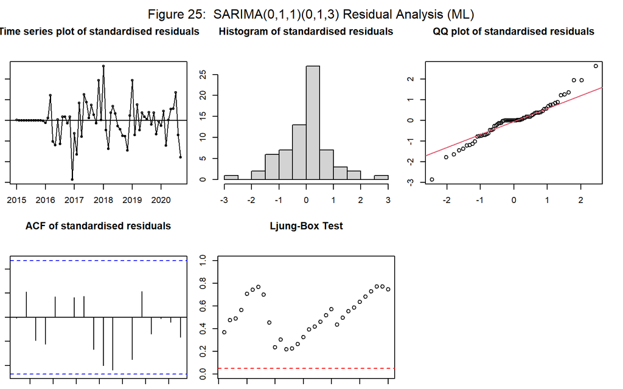

```
##
## z test of coefficients:
##
##       Estimate Std. Error z value  Pr(>|z|)
## ma1  -0.792971   0.164764 -4.8128 1.489e-06 ***
## sma1 -1.000633   0.847262 -1.1810    0.2376
## sma2 -0.016741   0.272201 -0.0615    0.9510
## sma3  0.018542   0.249494  0.0743    0.9408
## ---
## Signif. codes:  0 '***' 0.001 '**' 0.01 '*' 0.05 '.' 0.1 ' ' 1
```

It can be seen for the above model the MA(1) value is significant, however not the seasonal P and Q values. It can be seen in the residual analysis, there is no obvious trend in the residuals plot. However using the histogram of residuals and the QQ plot, it does not seem the residuals are normally distributed. This can be further seen by the Shapiro Wilks t-test which returned a p-value of 0.01 which is less than 0.05. However there is no significant lags in the ACF plot and all p values are above the confidence interval in the Ljung-Box test. Because the residuals are not normal, CSS is likely a better method over ML.

```r
# CSS METHOD
m4_011_CSS <- Parameter.estimation(Data_ts_agg,c(0,1,1),c(0,1,3),method="CSS",'26')
```

```
##
##  Shapiro-Wilk normality test
##
## data:  res.model
## W = 0.94238, p-value = 0.00321
```

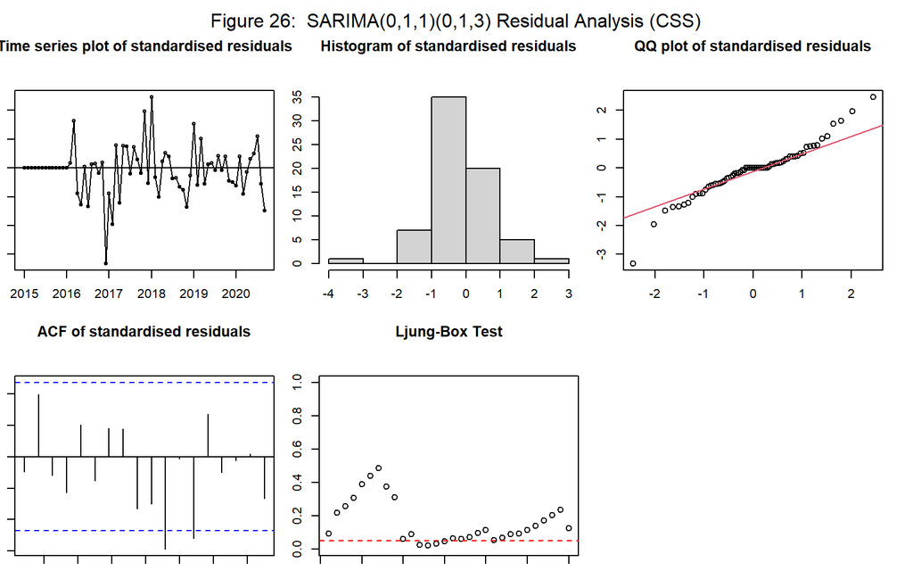

```
##
## z test of coefficients:
##
##       Estimate Std. Error z value  Pr(>|z|)
## ma1  -0.830103   0.119658 -6.9373 3.996e-12 ***
## sma1 -0.676582   0.155618 -4.3477 1.376e-05 ***
## sma2 -0.013952   0.220682 -0.0632    0.9496
## sma3 -0.041265   0.209363 -0.1971    0.8438
## ---
## Signif. codes:  0 '***' 0.001 '**' 0.01 '*' 0.05 '.' 0.1 ' ' 1
```

##### 1 - reducing Q value by 1

```r
# ML METHOD
m4_011_ML <- Parameter.estimation(Data_ts_agg,c(0,1,1),c(0,1,2),method="ML",'27')
```

```
##
##  Shapiro-Wilk normality test
##
## data:  res.model
## W = 0.9521, p-value = 0.01007
```

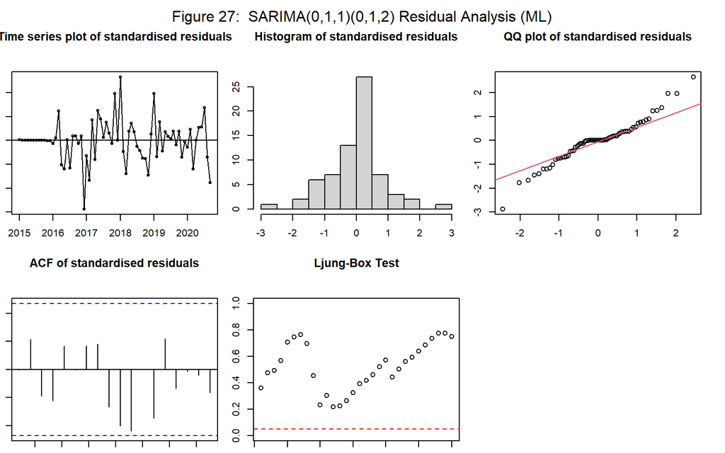

```
##
## z test of coefficients:
##
##        Estimate Std. Error z value  Pr(>|z|)
## ma1  -0.7974117  0.1535891 -5.1919 2.082e-07 ***
## sma1 -0.9976695  0.7282187 -1.3700    0.1707
## sma2 -0.0022906  0.1900177 -0.0121    0.9904
## ---
## Signif. codes:  0 '***' 0.001 '**' 0.01 '*' 0.05 '.' 0.1 ' ' 1
```

It can be seen for the above model the MA(1) value is significant, however not the seasonal P and Q values. It can be seen in the residual analysis, there is no obvious trend in the residuals plot. However using the histogram of residuals and the QQ plot, it does not seem the residuals are normally distributed. This can be further seen by the Shapiro Wilks t-test which returned a p-value of 0.01 which is less than 0.05. However there is no significant lags in the ACF plot and all p values are above the confidence interval in the Ljung-Box test.

#### 1 - reducing Q value by 2

```r
# ML METHOD
m4_011_ML <- Parameter.estimation(Data_ts_agg,c(0,1,1),c(0,1,1),method="ML",'28')
```

```
##
##  Shapiro-Wilk normality test
##
## data:  res.model
## W = 0.95199, p-value = 0.009934
```

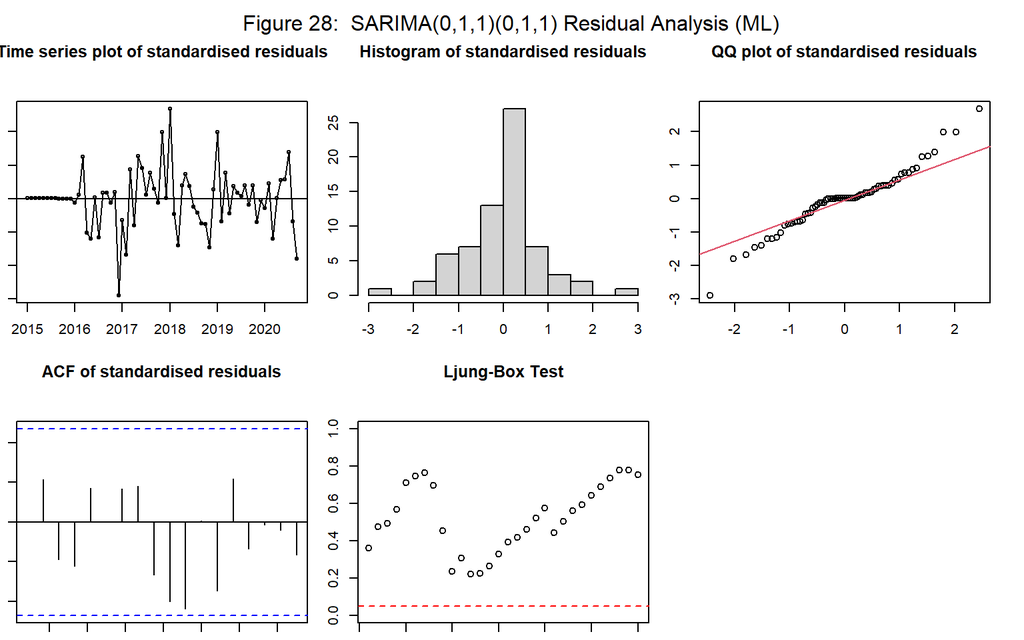

```
##
## z test of coefficients:
##
##      Estimate Std. Error z value  Pr(>|z|)
## ma1  -0.79829    0.13531 -5.8997 3.643e-09 ***
## sma1 -0.99918    0.72796 -1.3726    0.1699
## ---
## Signif. codes:  0 '***' 0.001 '**' 0.01 '*' 0.05 '.' 0.1 ' ' 1
```

It can be seen for the above model the MA(1) value is significant, however not the seasonal Q value. It can be seen in the residual analysis, there is no obvious trend in the residuals plot. However using the histogram of residuals and the QQ plot, it does not seem the residuals are normally distributed. This can be further seen by the Shapiro Wilks t-test which returned a p-value of 0.01 which is less than 0.05. However there is no significant lags in the ACF plot and all p values are above the confidence interval in the Ljung-Box test.

#### 1 - reducing Q value by 3 and increasing P

```r
# SARIMA(0,1,1)x(0,1,3)_12
# ML METHOD
m4_011_ML <- Parameter.estimation(Data_ts_agg,c(0,1,1),c(1,1,0),method="ML",'29')
```

```
##
##  Shapiro-Wilk normality test
##
## data:  res.model
## W = 0.94454, p-value = 0.004114
```

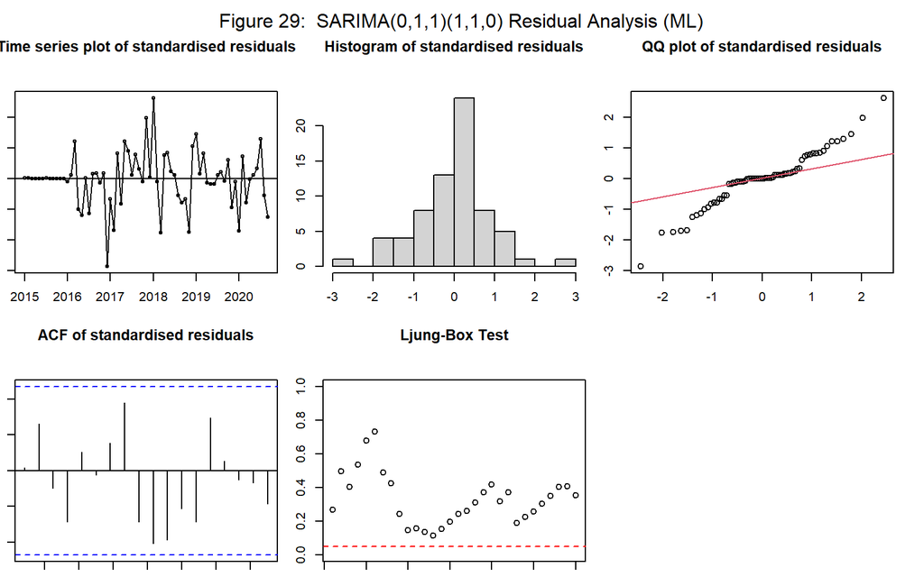

```
##
## z test of coefficients:
##
##      Estimate Std. Error z value  Pr(>|z|)
## ma1  -0.81526    0.14323 -5.6920 1.255e-08 ***
## sar1 -0.50536    0.12883 -3.9227 8.757e-05 ***
## ---
## Signif. codes:  0 '***' 0.001 '**' 0.01 '*' 0.05 '.' 0.1 ' ' 1
```

It can be seen for the above model the MA(1) value is significant and so is the seasonal AR(1) value. It can be seen in the residual analysis, there is no obvious trend in the residuals plot. However using the histogram of residuals and the QQ plot, it does not seem the residuals are normally distributed. This can be further seen by the Shapiro Wilks t-test which returned a p-value of 0.004 which is less than 0.05. However there is no significant lags in the ACF plot and all p values are above the confidence interval in the Ljung-Box test.

```r
# SARIMA(0,1,1)x(0,1,3)_12
# ML METHOD
m4_011_ML <- Parameter.estimation(Data_ts_agg,c(0,1,1),c(2,1,0),method="ML",'30')
```

```
##
##  Shapiro-Wilk normality test
##
## data:  res.model
## W = 0.95544, p-value = 0.01511
```

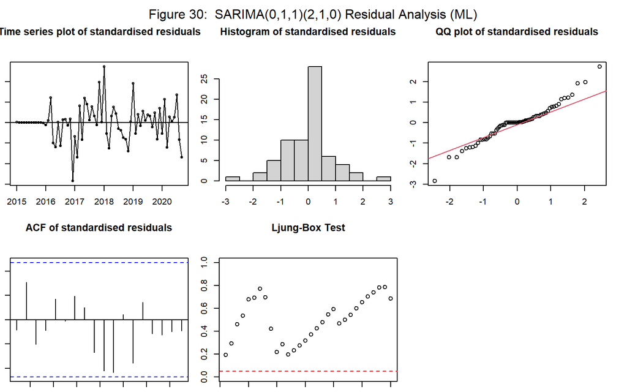

```
##
## z test of coefficients:
##
##      Estimate Std. Error z value  Pr(>|z|)
## ma1  -0.81680    0.15595 -5.2374 1.628e-07 ***
## sar1 -0.71999    0.15954 -4.5128 6.397e-06 ***
## sar2 -0.41048    0.14444 -2.8419  0.004485 **
## ---
## Signif. codes:  0 '***' 0.001 '**' 0.01 '*' 0.05 '.' 0.1 ' ' 1
```

It can be seen for the above model the MA(1) value is significant and so is the seasonal AR(1) and AR(2) values. It can be seen in the residual analysis, there is no obvious trend in the residuals plot. However using the histogram of residuals and the QQ plot, it does not seem the residuals are normally distributed. This can be further seen by the Shapiro Wilks t-test which returned a p-value of 0.015 which is less than 0.05. However there is no significant lags in the ACF plot and all p values are above the confidence interval in the Ljung-Box test. Due to the higher number of significant seasonal perameters in this model compared to previous, it is more likely to capture the seasonal trend to a greater degree. This is thew most optimal model as increasing any further causes and reduction in the number of significant parameters. The updated seasonal parameters will be used now to check the ARIMA p and q values for previously identified possible models.

Final seasonal parameters:

- P = 2
- D = 1
- Q = 0

#### SARIMA(1, 1, 1)(2, 1, 0)_12

```r
# SARIMA(1,1,1)x(2,1,0)_12
# ML METHOD
base_111_ML <- Parameter.estimation(Data_ts_agg,c(1,1,1),c(2,1,0),method="ML",'31')
```

```
##
##  Shapiro-Wilk normality test
##
## data:  res.model
## W = 0.95747, p-value = 0.01942
```

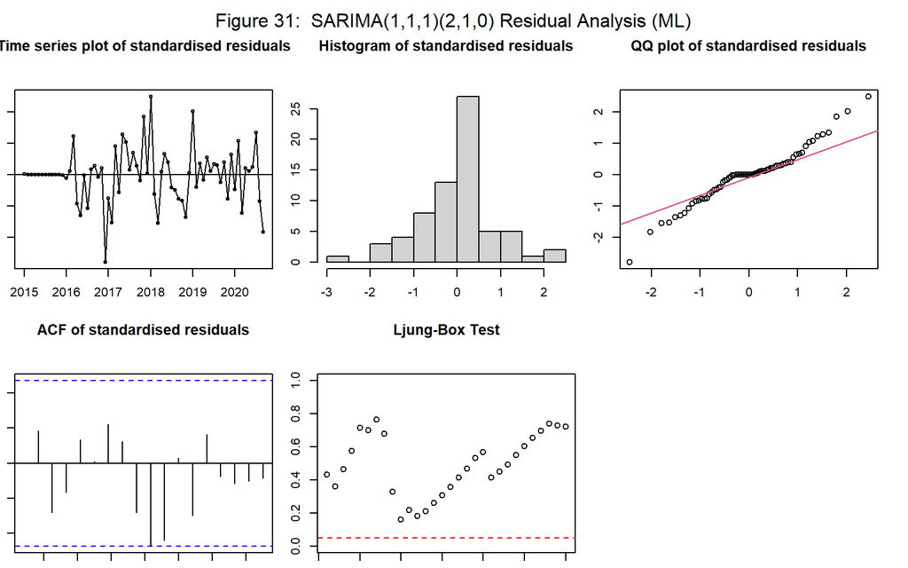

```
##
## z test of coefficients:
##
##      Estimate Std. Error z value  Pr(>|z|)
## ar1  -0.11184    0.30303 -0.3691   0.71209
## ma1  -0.72021    0.29987 -2.4017   0.01632 *
## sar1 -0.70556    0.17030 -4.1429 3.429e-05 ***
## sar2 -0.42200    0.15851 -2.6624   0.00776 **
## ---
## Signif. codes:  0 '***' 0.001 '**' 0.01 '*' 0.05 '.' 0.1 ' ' 1
```

```r
# CSS METHOD
base_111_CSS <- Parameter.estimation(Data_ts_agg,c(1,1,1),c(2,1,0),method="CSS",'32')
```

```
##
##  Shapiro-Wilk normality test
##
## data:  res.model
## W = 0.78084, p-value = 9.102e-09
```

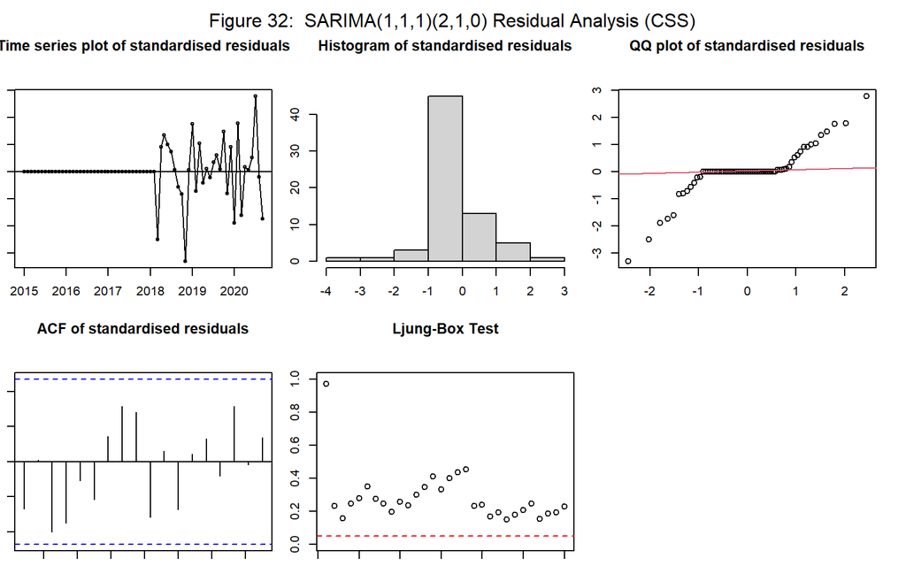

```
##
## z test of coefficients:
##
##        Estimate Std. Error  z value  Pr(>|z|)
## ar1   0.0875129  0.0023623   37.046 < 2.2e-16 ***
## ma1  -1.2745978  0.0117095 -108.852 < 2.2e-16 ***
## sar1 -0.5545065  0.0025092 -220.991 < 2.2e-16 ***
## sar2 -0.1613516  0.0087511  -18.438 < 2.2e-16 ***
## ---
## Signif. codes:  0 '***' 0.001 '**' 0.01 '*' 0.05 '.' 0.1 ' ' 1
```